# PROJET 4a : le modèle SIR – RMD

14 décembre, 2020

# I. Consigne et objectifs

Nous allons étudier une problématique biologique (au sens large) par des simulations avec R.

Pour ce faire nous allons proposer:

- un code fonctionnel dans un package R
- une présentation créée avec Rmarkdown
- le partage du code et de la présentation avec github

Le projet que nous allons traiter est le **Projet 4 : le modèle SIR**.

# II. Résolution du projet

### 1. Présentation et compréhension du problème

#### 1.1. Le Modèle SIR : dynamique des épidémies

Le **modèle SIR** propose de représenter une épidémie en compartimentant les individus d’une population N constante (on néglige la natalité et la mortalité) en sous populations dynamiques au cours du temps *t* : *sains* **$S(t)$**, *infectés* **$I(t)$** et *retirés* **$R(t)$**. Dans ce modèle, on considère les personnes retirées comme immunisées ou mortes, c’est pourquoi on différentie les deux sous-populations $S(t)$ et $R(t)$.

Le modèle SIR est donc un modèle permettant de modeliser une épidémie, c’est-à-dire de prédire la transmission d’un pathogène entre les individus, les infections, et qu’il ne prend pas en compte la prédiction de la mortalité de l’épidémie.

On sait que:
$$N = S(t) + I(t) + R(t) = 1$$

Précisons que l’état du système à un instant t donné est défini par les trois nombres $S(t)$, $I(t)$, $R(t)$ sont des fractions de la population et qu’on suppose qu’il y a beaucoup de personnes au sein d’une population et qu’on peut donc oublier qu’on a des nombres entiers, c’est-à-dire qu’il faudra considérer S,I et R comme des variables continues.

Introduisons deux variables $\beta$ et $\gamma$ qui nous permettront de définir le **taux de transmission $\beta$** et le **taux de guérison $\gamma$**.

$$\beta\ \ \ \ \ \ \ \ \gamma\\ S \longrightarrow I \longrightarrow R$$

Le taux de transmission $\beta$ est donc le passage des personnes saines à infectées et le taux de guérison $\gamma$ est le passage des personnes infectées à retirées.

#### 1.2. Le système d’équations différentielles

Nous allons donc étudier l’évolution des sous populations en supposant que la variation de $S(t)$,$I(t)$,$R(t)$ à un instant donné t est une fonction simple de la situation à ce même instant, c’est-à-dire que l’évolution est régie par trois équations différentielles non linéaires à trois inconnues.

Elles représentent un taux d’accroissement par rapport au temps :

$$\begin{equation}
\left\{
\begin{array}{l}
S'(t) = \frac{dS(t)}{dt} = - \beta S(t) I(t)\\
I'(t) = \frac{dI(t)}{dt} = \beta S(t) I(t) - \gamma I(t)\\
R'(t) = \frac{dR(t)}{dt} = \gamma I(t)
\end{array}
\right.
\end{equation}$$

De plus,on note :
$$S'(t) + I'(t) + R'(t) = 0$$

Ces 3 équations nous permettent d’obtenir des informations qualitatives intéressantes sur la façon dont l’épidémie se propage.

L’objectif du projet est d’estimer le temps du pic des infectés par des simulations avec R.

#### 1.3. Définition du coefficient R0

Dans notre étude, nous considérons que le nombre de personnes infectées tend vers 0, c’est-à-dire que l’épidémie prend fin et les populations se stabilisent.

Dans les conditions initiales, on donne S(0), I(0) et R(0) :

- $0 \leqslant S(0)= s_0 \leqslant 1$ (valeur très proche de 1)
- $0 \leqslant I(0)= i_0 \leqslant 1$ (valeur très proche de 0)
- $R(0)= r_0 =0$ (on considère aucune personne morte ou immunisée au début de l’épidémie)

A t=0 on peut écrire :

$$\begin{equation}
\left\{
\begin{array}{l}
S'(0) = - \beta S(0) I(0)\\
I'(0) = \beta S(t) I(0) - \gamma I(0)\\
R'(0) = \gamma I(0)
\end{array}
\right.
\end{equation}$$

Nous allons définir le **taux de reproduction $R_0$** comme le nombre moyen de cas secondaires produit par un individu infectieux au cours de sa période contagieuse. La valeur que prend $R_0$ determine donc le nombre de personnes que va infecter une personne déja malade.

Reprenons l’équation 2 :

$$I'(t) = \beta S(t) I(t) - \gamma I(t) \\= \gamma I (t)(\frac{\beta I(t) S(t)}{\gamma I(t)} -1) \\= \gamma I(t) (\frac{\beta S(t)}{\gamma } -1) \\ =\gamma I(t) (R_0 S(t) -1)$$
On identifie $R_0 = \frac{\beta}{\gamma}$ comme le *coefficient de contact*.

C’est ce coefficient là que les gouvernements tentent de maitriser lors de la propagation d’une épidémie. Notamment avec les mesures de confinement actuelles pour limiter le contact entre les personnes saines et malades, et ainsi, réduire les contaminations.

Nous allons pouvoir evaluer le comportement de I’(t) grâce à ce coefficient $R_0$. En effet, nous savons que $\gamma I$ est forcément positif, donc c’est bien la valeur de $R_0 S(t) - 1$ qui determine le signe de $\gamma I'(t)$.

- Si $R_0 < 1/S_0$ alors $I'(0) < 0$, ce qui veut dire que $I(t)$ *décroit*, l’épidémie prend fin.
- Si $R_0 > 1/S_0 = 1/p$ alors $I'(0) > 0$, ce qui veut dire que $I(t)$ *croit*, et atteint une valeur maximale : c’est le **pic de l’épidemie**.

### 2. Simulation de l’épidémie avec R

#### 2.1. Packages

Installation du package crée pour ce projet :

```r
#devtools::install_github("ZoeGerber/ModeleSIR")
library(ModeleSIR)
```

Dans ce package se trouvent toutes les fonctions nécessaires pour réaliser ces simulations du modèle SIR et prédire le pic des infectés.

Nous nous servirons également du package ggplot2 pour tracer nos courbes :

```r
library(ggplot2)
```

#### 2.2. Résolution du système numériquement

On veut passer d’un modèle continu au discret.

Pendant une unité de temps $\Delta t$, le nombre d’individus sains passe de $S(t)$ à $S(t + \Delta t)$, et la variation de $S(t + \Delta t)–S(t)$ peut s’écrire :

$$\begin{equation}
\left\{
\begin{array}{l}
\frac{dS(t)}{dt} = \frac{S(t + \Delta t)-S(t)}{\Delta t} \\
\frac{dI(t)}{dt} = \frac{I(t + \Delta t) -I(t)}{\Delta t} \\
\frac{dS(t)}{dt} = \frac{R(t + \Delta t) -R(t)}{\Delta t}
\end{array}
\right.
\end{equation}$$

Nous voulons isoler $S(t + \Delta t)$ , $I(t + \Delta t)$ et $R(t + \Delta t)$ afin de former une suite :

$$\begin{equation}
\left\{
\begin{array}{l}
S(t + \Delta t) -S(t) = - \beta S(t) I(t) \Delta t\\
I(t + \Delta t) -I(t) = \beta S(t) I(t) - \gamma I(t) \Delta t\\
R(t + \Delta t) -R(t) = \gamma I(t) \Delta t
\end{array}
\right.
\end{equation}$$

$$\begin{equation}
\left\{
\begin{array}{l}
S(t + \Delta t) = - \beta S(t) I(t) \Delta t +S(t)\\
I(t + \Delta t) = [\beta S(t) I(t) - \gamma I(t)] \Delta t + I(t)\\
R(t + \Delta t) = \gamma I(t) \Delta t +R(t)
\end{array}
\right.
\end{equation}$$

Nous pouvons donc calculer les valeurs de S,I et R pour chaque valeurs de t données, avec $\Delta t$, fixé.

#### 2.3. Calculs

Si nous réalisions les calcul à la main nous pourrions donner le terme suivant grâce au terme précédent, comme suit :

Fixons pour l’exemple $\beta = 0.5$, $\gamma = 0.03$ et $\Delta t = 0.01$.

[output not shown]

Ce qui va nous interresser, c’est de pouvoir réaliser ces calculs avec R.

#### 2.4. Initialisation

Au début de l’épidémie (t=0) on a $p$ personnes saines, et $1-p$ personnes infectées.

Il n’y a aucune personne retirée au début de l’épidémie.

*$p$* est donc la proportion de personnes saines au commencement de l’épidémie. (Cf fonction dans le package)

Les paramètres qui vont pouvoir être modifiés et ajustés au cours des simulations sont :

- Le taux de transmission $\beta$
- Le taux de guérison $\gamma$
- Par extension de ces deux paramètres, le $R_0$
- La proportion de personnes $p$ saines au début de l’épidémie
- La durée de la simulation (vecteur donné en jours)

La fonction initSir(p) calcule les fractions initiales (à t=0) de N qui sont Sains, Infectés et Retirés :

```r
initSir(0.9)
```

```
## [1] 0.9 0.1 0.0
```

Les fonctions de tirage donnent des valeurs aléatoires aux paramètres $\beta$ et $\gamma$ (qu’on suppose ne pas connaitre) :

```r
beta <- tirageBeta(0.01,0.99)
print(beta)
```

```
## [1] 0.7352401
```

```r
gamma <- tirageGamma(0.01,0.99)
print(gamma)
```

```
## [1] 0.03527209
```

```r
R0 <- beta/gamma
print(R0)
```

```
## [1] 20.84481
```

#### 2.5 Courbes

Pour cet exemple, choisissons :

On part donc du **postulat** que le virus se transmet facilement, et dont on guérit plutôt mal. La valeur du $R_0$ est de 40.

```r
df <- sir(100,0.01,0.7888999,0.8,0.02)

head(df)
```

|  | j | resS | resI | resR |
| --- | --- | --- | --- | --- |
| 1 | 1 | 0.7888999 | 0.2111001 | 0.000000e+00 |
| 2 | 2 | 0.7875676 | 0.2123902 | 4.222002e-05 |
| 3 | 3 | 0.7862294 | 0.2136859 | 8.469805e-05 |
| 4 | 4 | 0.7848854 | 0.2149872 | 1.274352e-04 |
| 5 | 5 | 0.7835355 | 0.2162941 | 1.704327e-04 |
| 6 | 6 | 0.7821797 | 0.2176066 | 2.136915e-04 |

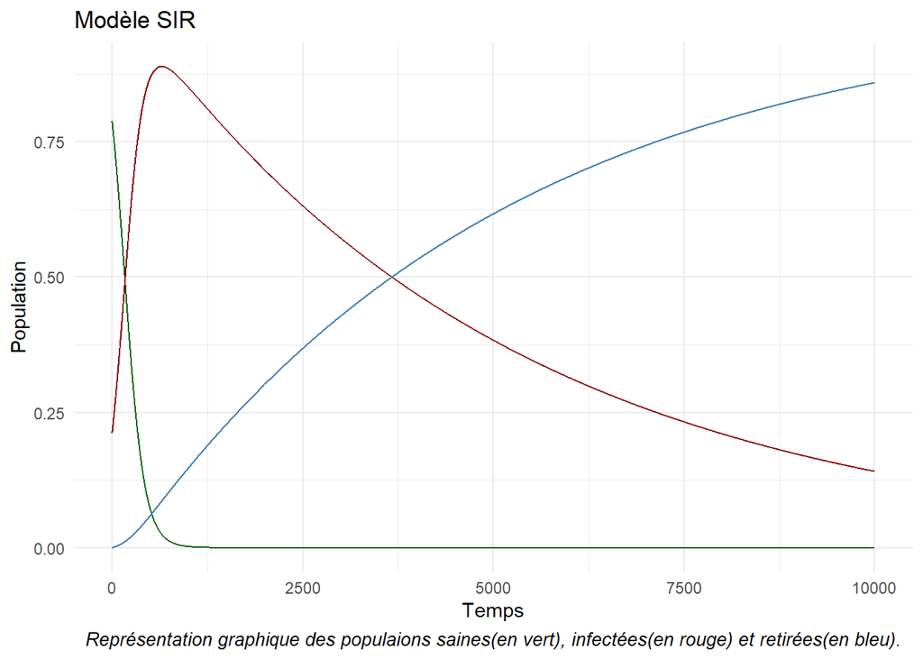

```r
theme_set(theme_minimal())

ggplot(df, aes(x=j)) + geom_line(aes(y = resS), color = "darkgreen") + geom_line(aes(y = resI),color = "darkred") + geom_line(aes(y = resR), color="steelblue") + labs(title = "Modèle SIR", x = "Temps", y="Population", color="L") + labs(caption = "Représentation graphique des populaions saines(en vert), infectées(en rouge) et retirées(en bleu).")+ theme(plot.caption = element_text(hjust = 0.5, face = "italic", size =10))
```

```r
picI(0.8,0.02,df)
```

| PicI | datePicI | R0pic |
| --- | --- | --- |
| 0.8889601 | 651 | 40 |

En rouge la courbes des personnes **Infectées**, en bleu celle des **Retirées** et en vert celle des personnes **Saines**

Cherchons des pistes d’améliorations.

## 3. Simulations et analyses

Un fois notre graphe fonctionnel, nous pouvons donc nous amuser à modifier la valeur des paramètres et ainsi ammener des premières conclusions à ce modèle.

### 3.1 Taux de guérison $\gamma$

*Hypothèse 1* : Nous pouvons agir sur la guérison des personnes malades (médicament ou système de santé performant par exemple)

Augmentons donc le taux de guérison $\gamma$ :

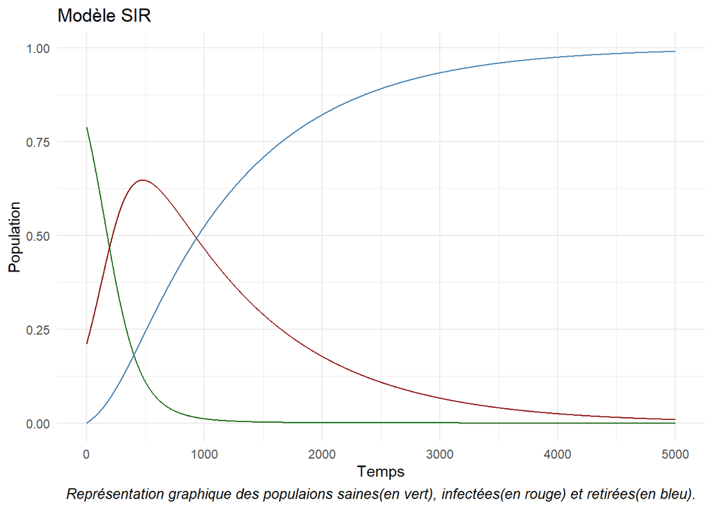

```r
df2 <- sir(50,0.01,0.78885555,0.8,0.099)
theme_set(theme_minimal())

ggplot(df2, aes(x=j)) + geom_line(aes(y = resS), color = "darkgreen") + geom_line(aes(y = resI),color = "darkred") + geom_line(aes(y = resR), color="steelblue") + labs(title = "Modèle SIR", x = "Temps", y="Population", color="L") + labs(caption = "Représentation graphique des populaions saines(en vert), infectées(en rouge) et retirées(en bleu).")+ theme(plot.caption = element_text(hjust = 0.5, face = "italic", size =10))
```

```r
picI(0.8,0.099,df2)
```

| PicI | datePicI | R0pic |
| --- | --- | --- |
| 0.6475086 | 477 | 8.080808 |

On observe directement que le pic d’infectés est beaucoup moins haut (un peu plus de 50% (64,7%) de la population à été malade).

### 3.2 Taux de transmission $\beta$

*Hypothèse 2* : Nous pouvons agir sur l’infection des personnes saines (confinement, vaccin ou distantiacion sociale par exemple)

Diminuons donc le taux de transmission $\beta$ :

- Taux de transmission $\beta = 0.06$
- Taux de guérison $\gamma=0.02$
- Proportion de personnes saines $p=0.78885555$ au début de l’épidémie
- Durée de la simulation : 100 jours
- $\Delta t= 0.01$

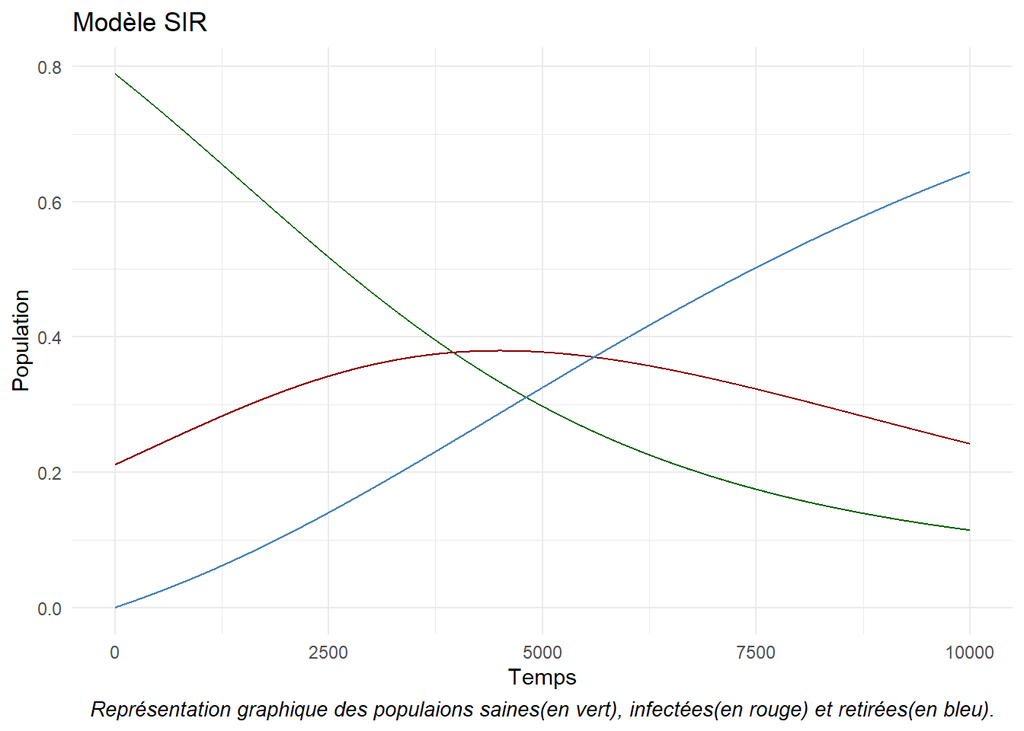

```r
df3 <- sir(100,0.01,0.78885555,0.06,0.02)
theme_set(theme_minimal())

ggplot(df3, aes(x=j)) + geom_line(aes(y = resS), color = "darkgreen") + geom_line(aes(y = resI),color = "darkred") + geom_line(aes(y = resR), color="steelblue") + labs(title = "Modèle SIR", x = "Temps", y="Population", color="L") + labs(caption = "Représentation graphique des populaions saines(en vert), infectées(en rouge) et retirées(en bleu).")+ theme(plot.caption = element_text(hjust = 0.5, face = "italic", size =10))
```

```r
picI(0.06,0.02,df3)
```

| PicI | datePicI | R0pic |
| --- | --- | --- |
| 0.3795481 | 4500 | 3 |

### 3.3 Taux de guérion $\gamma$ et taux de transmission $\beta$

*Hypothèse 3* : Nous pouvons agir les deux paramètres en même temps.

Diminuons donc le taux de transmission $\beta$ et augmentons le taux de guérion $\gamma$ :

- Taux de transmission $\beta = 0.06$
- Taux de guérison $\gamma=0.099$
- Proportion de personnes saines $p=0.78885555$ au début de l’épidémie
- Durée de la simulation : 100jours
- $\Delta t= 0.01$

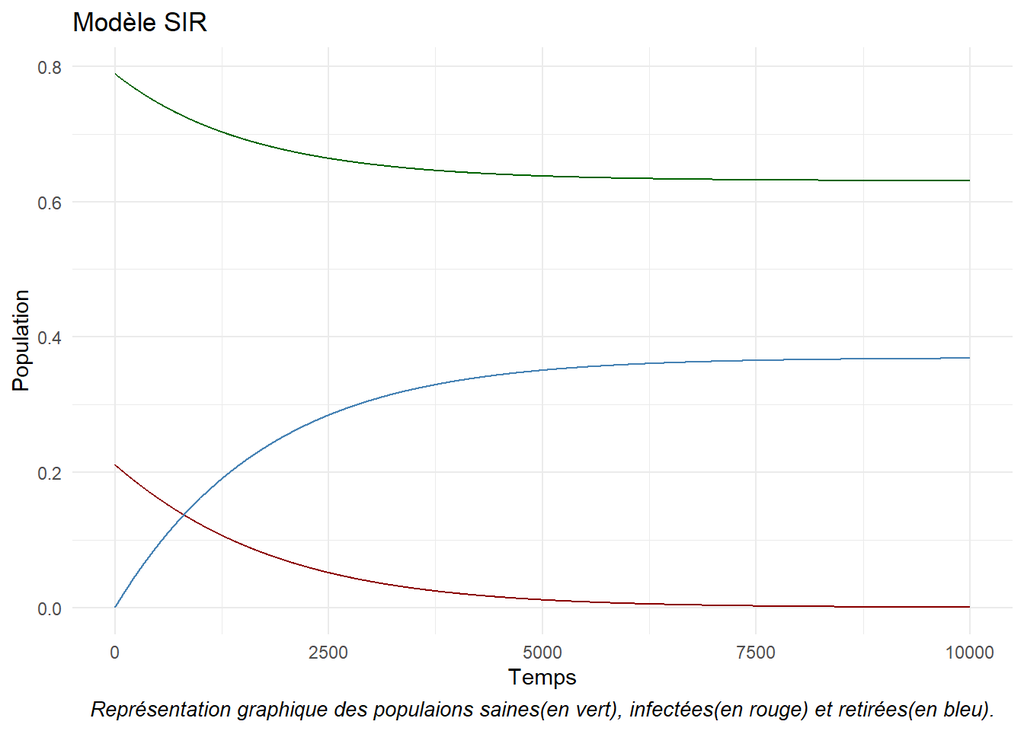

```r
df4 <- sir(100,0.01,0.78885555,0.06,0.099)
theme_set(theme_minimal())

ggplot(df4, aes(x=j)) + geom_line(aes(y = resS), color = "darkgreen") + geom_line(aes(y = resI),color = "darkred") + geom_line(aes(y = resR), color="steelblue") + labs(title = "Modèle SIR", x = "Temps", y="Population", color="L") + labs(caption = "Représentation graphique des populaions saines(en vert), infectées(en rouge) et retirées(en bleu).")+ theme(plot.caption = element_text(hjust = 0.5, face = "italic", size =10))
```

```r
picI(0.06,0.099,df4)
```

| PicI | datePicI | R0pic |
| --- | --- | --- |
| 0.2111445 | 1 | 0.6060606 |

On observe clairement que les mesures prises ont joué un role dans la gestion de cette épidémie ! Certaines personnes n’ont même jamais entendu parler de ce virus il semblerait ! Les personnes infectées contaminaient moins de 1 personnes (0.6).

# III. Réalisation d’une étude par simulation d’une quantité caractéristique

Dans notre étude précédente, nous avons modélisé différentes courbes avec des valeurs du taux de reproduction $R_0$ maitrisées, car on fixait $\beta$ et $\gamma$.

En réalité, lors d’une épidémie, on ne connaît pas le $R_0$ précisément, et c’est lui qu’on cherche à determiner.

En effet, la connaissance précise du $R_0$ nous permet de savoir s’il faut prendre des mesures, et quand les prendre, comme imposer un confinement (très restricif ou pas).

Reprenons des valeurs inconnues de $\beta$ et $\gamma$, et regardons comment le $R_0$ nous permet de prédire le pic.

Si on suppose $R_0$ entre 2 bornes (>1 [pas d’épidémie] et 20 [épidémie incontrôlée] par exemple), on pourra être capable de déterminer la valeur du pic et le temps du pic.

### 1. Seuil de tolérance des hopitaux

On cherche à avoir un pic d’infectés qui ne dépasse par une certaine valeur (là où les hopitaux ne peuvent plus gérer les cas).

Avec des conditions initiales $s0$ et $i0$ données, on veut trouver quand et de combien réduire le $R_0$ pour éviter de dépasser ce seuil, soit trouver quand imposer un confinement et de quelle nature (très restricif ou peu restrictif)

Définissons arbitrairement notre seuil comme le moment ou les infectés seraient à plus de 45% de la population.

```r
beta <- tirageBeta(0.01,0.99)
print(beta)
```

```
## [1] 0.5085714
```

```r
gamma <- tirageGamma(0.01,0.99)
print(gamma)
```

```
## [1] 0.1883923
```

```r
R0 <- beta/gamma
print(R0)
```

```
## [1] 2.699534
```

```r
s <- sir(100,0.1,0.7888999,beta,gamma)
summary(s, simplify=T)
```

```
##        j               resS              resI                resR
##  Min.   :   1.0   Min.   :0.06165   Min.   :0.0000002   Min.   :0.0000
##  1st Qu.: 250.8   1st Qu.:0.06166   1st Qu.:0.0000116   1st Qu.:0.9008
##  Median : 500.5   Median :0.06178   Median :0.0006066   Median :0.9376
##  Mean   : 500.5   Mean   :0.10182   Mean   :0.0498081   Mean   :0.8484
##  3rd Qu.: 750.2   3rd Qu.:0.06823   3rd Qu.:0.0309525   3rd Qu.:0.9383
##  Max.   :1000.0   Max.   :0.78890   Max.   :0.3517269   Max.   :0.9383
```

```r
head(s)
```

|  | j | resS | resI | resR |
| --- | --- | --- | --- | --- |
| 1 | 1 | 0.7888999 | 0.2111001 | 0.000000000 |
| 2 | 2 | 0.7804303 | 0.2155927 | 0.003976963 |
| 3 | 3 | 0.7718733 | 0.2200881 | 0.008038563 |
| 4 | 4 | 0.7632337 | 0.2245814 | 0.012184852 |
| 5 | 5 | 0.7545164 | 0.2290678 | 0.016415793 |
| 6 | 6 | 0.7457265 | 0.2335423 | 0.020731253 |

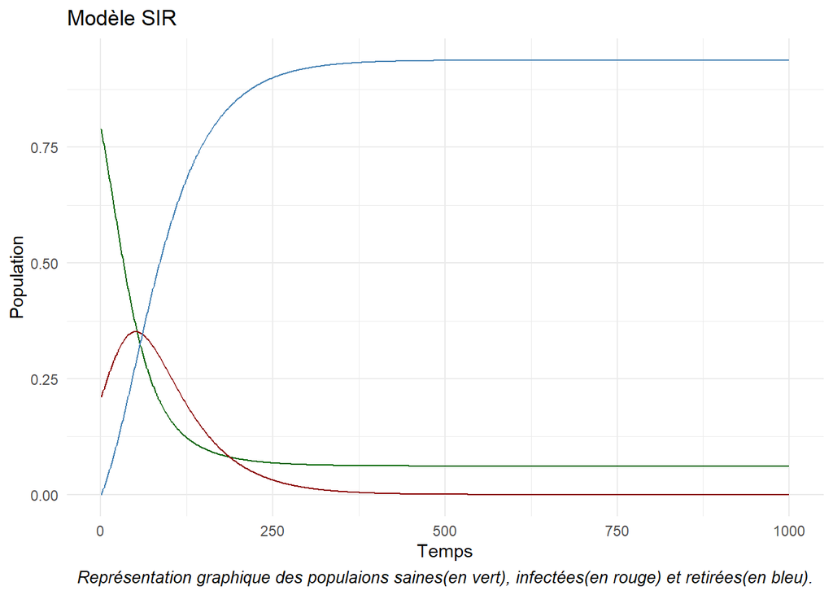

```r
theme_set(theme_minimal())

ggplot(s, aes(x=j)) + geom_line(aes(y = resS), color = "darkgreen") + geom_line(aes(y = resI),color = "darkred") + geom_line(aes(y = resR), color="steelblue") + labs(title = "Modèle SIR", x = "Temps", y="Population", color="L") + labs(caption = "Représentation graphique des populaions saines(en vert), infectées(en rouge) et retirées(en bleu).")+ theme(plot.caption = element_text(hjust = 0.5, face = "italic", size =10))
```

```r
picI(beta,gamma,s)
```

| PicI | datePicI | R0pic |
| --- | --- | --- |
| 0.3517269 | 51 | 2.699534 |

## 2. Replicate()

Le replicate(n,fun) permet de réaliser la simulation de nombreuses fois. La fonction picIsimu() prend en paramètre $t$, $\Delta t$, $p$ et les bornes min et max des parmètres $\beta$ et $\gamma$.

```r
list_res <- data.frame(replicate(50,picIsimu(10,0.01,0.7888999,0.01,0.99), simplify=T))
print(list_res)
```

```
##                 X1        X2        X3        X4        X5        X6        X7
## PicI     0.2111001 0.4477892 0.7848347 0.3836522 0.5875408 0.2111001 0.2111001
## datePicI         1       562       583       641       675         1         1
## R0pic    0.1818865  3.794347  16.56312  3.041492  6.311385   1.25372 0.6096544
##                 X8        X9       X10       X11       X12       X13       X14
## PicI     0.2111001 0.2111001 0.2111001 0.2111001 0.3924866 0.2111001 0.4433791
## datePicI         1         1         1         1       625         1       735
## R0pic    0.1504525 0.8237816 0.5901644 0.7617644  3.135974 0.8705853  3.737847
##               X15       X16       X17       X18       X19       X20       X21
## PicI     0.220678 0.2111001 0.7938307 0.2157321 0.2111001 0.2111001 0.2111001
## datePicI      128         1       514       179         1         1         1
## R0pic    1.493343 0.6487432  17.56495  1.418053 0.4686662 0.2875219  1.055579
##                X22       X23       X24       X25       X26       X27       X28
## PicI     0.2111001 0.7286933 0.2111001 0.4159055 0.2111001 0.2111001 0.2111001
## datePicI         1       472         1       628         1         1         1
## R0pic     1.075564  11.92684 0.8953681  3.399776 0.5592104 0.3842242 0.7709698
##                 X29       X30       X31       X32       X33       X34       X35
## PicI      0.2111001 0.2245741 0.2111001 0.2111001 0.5856333 0.2111001 0.2192293
## datePicI          1        99         1         1       394         1       145
## R0pic    0.01532444  1.542469 0.2977674 0.9788137  6.258616 0.5765859  1.473305
##                X36       X37       X38       X39       X40       X41       X42
## PicI     0.2111001 0.2111001 0.2189634 0.2112749 0.8214044 0.2111001 0.2111001
## datePicI         1         1        99        16       717         1         1
## R0pic    0.3702867 0.7788195  1.469118  1.293832  21.38607 0.2046594 0.7980052
##                X43      X44       X45       X46       X47       X48       X49
## PicI     0.2111001 0.231211 0.2188971 0.2111001 0.2111001 0.2111001 0.2111001
## datePicI         1      141       147         1         1         1         1
## R0pic     1.229363 1.617737  1.468514  1.018111 0.5579299 0.3316471  0.729686
##                X50
## PicI     0.2663559
## datePicI       236
## R0pic     1.948692
```

```r
concat <- do.call(rbind.data.frame,list_res)
head(concat)
```

|  | PicI | datePicI | R0pic |
| --- | --- | --- | --- |
| X1 | 0.2111001 | 1 | 0.1818865 |
| X2 | 0.4477892 | 562 | 3.7943470 |
| X3 | 0.7848347 | 583 | 16.5631244 |
| X4 | 0.3836522 | 641 | 3.0414916 |
| X5 | 0.5875408 | 675 | 6.3113851 |
| X6 | 0.2111001 | 1 | 1.2537204 |

```r
tail(concat)
```

|  | PicI | datePicI | R0pic |
| --- | --- | --- | --- |
| X45 | 0.2188971 | 147 | 1.4685144 |
| X46 | 0.2111001 | 1 | 1.0181108 |
| X47 | 0.2111001 | 1 | 0.5579299 |
| X48 | 0.2111001 | 1 | 0.3316471 |
| X49 | 0.2111001 | 1 | 0.7296860 |
| X50 | 0.2663559 | 236 | 1.9486919 |

```r
orderConcat <- concat[order(concat[,3],decreasing=F),]
print(orderConcat)
```

```
##          PicI datePicI       R0pic
## X29 0.2111001        1  0.01532444
## X8  0.2111001        1  0.15045249
## X1  0.2111001        1  0.18188647
## X41 0.2111001        1  0.20465943
## X20 0.2111001        1  0.28752190
## X31 0.2111001        1  0.29776745
## X48 0.2111001        1  0.33164708
## X36 0.2111001        1  0.37028673
## X27 0.2111001        1  0.38422421
## X19 0.2111001        1  0.46866620
## X47 0.2111001        1  0.55792992
## X26 0.2111001        1  0.55921041
## X34 0.2111001        1  0.57658587
## X10 0.2111001        1  0.59016439
## X7  0.2111001        1  0.60965444
## X16 0.2111001        1  0.64874325
## X49 0.2111001        1  0.72968596
## X11 0.2111001        1  0.76176441
## X28 0.2111001        1  0.77096977
## X37 0.2111001        1  0.77881948
## X42 0.2111001        1  0.79800517
## X9  0.2111001        1  0.82378159
## X13 0.2111001        1  0.87058532
## X24 0.2111001        1  0.89536812
## X32 0.2111001        1  0.97881368
## X46 0.2111001        1  1.01811083
## X21 0.2111001        1  1.05557923
## X22 0.2111001        1  1.07556409
## X43 0.2111001        1  1.22936253
## X6  0.2111001        1  1.25372042
## X39 0.2112749       16  1.29383161
## X18 0.2157321      179  1.41805283
## X45 0.2188971      147  1.46851439
## X38 0.2189634       99  1.46911793
## X35 0.2192293      145  1.47330515
## X15 0.2206780      128  1.49334311
## X30 0.2245741       99  1.54246925
## X44 0.2312110      141  1.61773707
## X50 0.2663559      236  1.94869190
## X4  0.3836522      641  3.04149161
## X12 0.3924866      625  3.13597415
## X25 0.4159055      628  3.39977641
## X14 0.4433791      735  3.73784719
## X2  0.4477892      562  3.79434699
## X33 0.5856333      394  6.25861553
## X5  0.5875408      675  6.31138508
## X23 0.7286933      472 11.92683809
## X3  0.7848347      583 16.56312443
## X17 0.7938307      514 17.56495128
## X40 0.8214044      717 21.38607344
```

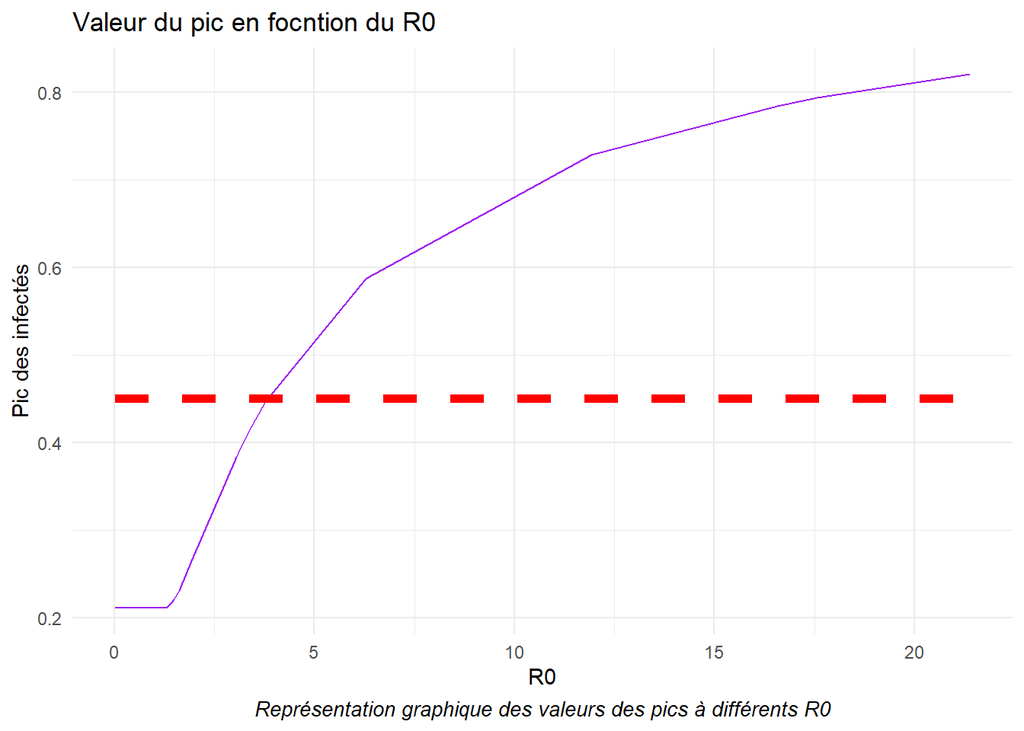

```r
ggplot(orderConcat, aes(x = R0pic)) + geom_line(aes(y = PicI), col="purple")+geom_line(aes(y = 0.45), col="red", linetype = "dashed", size=2)+ labs(title = "Valeur du pic en focntion du R0", x = "R0", y="Pic des infectés", color="red") + labs(caption = "Représentation graphique des valeurs des pics à différents R0")+ theme(plot.caption = element_text(hjust = 0.5, face = "italic", size =10))
```

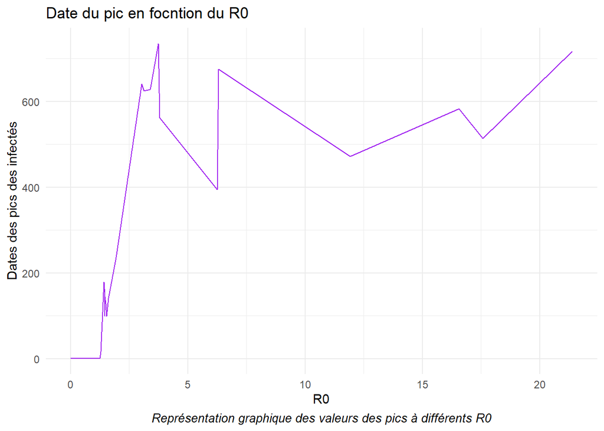

```r
 ggplot(orderConcat, aes(x = R0pic)) + geom_line(aes(y = datePicI), col="purple")+ labs(title = "Date du pic en focntion du R0", x = "R0", y="Dates des pics des infectés", color="red") + labs(caption = "Représentation graphique des valeurs des pics à différents R0")+ theme(plot.caption = element_text(hjust = 0.5, face = "italic", size =10))
```

A partir de quelle valeur du $R_0$ les hopitaux sont-ils débordés ?

## 3. Conclusion

Nous avons tenté de démontrer la corrélation entre la valeur aléatoire du $R_0$ et la date où le nombre d’infectés sera à son maximun.

L’objectif était d’éviter que le pic de personnes malades ne dépasse une certaine valeur arbitraire (nous avions choisi 45% de la population), car il fallait supposer que les capacités hospitalières ou de prise en charge des malades n’étaient pas extensibles. Ce genre de seuil est valable actuellement avec la pandémie que nous vivons.

En effet, il y a un nombre $x$ de places en réanimation par exemple, et si le nombre de personnes necessitant une place était supérieur à la capacité d’acceuil, cela aurait des conséquences dramatiques.

Il est donc nécessaire de pouvoir prévoir quand devrait arriver le pic, et determiner s’il va depasser la valeur critique seuil. Nous determinons alors le $R_0$ acceptable, et s’il s’avère que la valeur du $R_0$ de l’épidémie est au dessus, il faut vite prendre des mesures pour le faire diminuer.

Nous avions vu plus haut dans nos simulations qu’il était possible de diminuer le **taux de transmission** $\beta$ par exemple, en instaurant une distanciation sociale, ou en rendant obligatoire le port du masque dans les espaces clos. Si les scientifiques et les médecins parvenaient à trouver un médicament efficace, cela pourra augmenter le **taux de guérison** $\gamma$.

# IV. Complexification et réalisme du modèle SIR

### 1. Réalisme

Le modèle SIR est un modèle simple, qui considèrait une population constante au cours du temps, où les naissances et la mortalité étaient négligées.

En effet, pour se rapprocher de la réalité il faudrait prendre en compte ces paramètres.

De plus, lors d’une épidémie, il est possible de mettre en place des mesures pour réduire le nombre de malades ou de morts. On peut par exemple décider de confiner la population si le taux de transmission $\beta$ du pathogène est élevé. Ou alors lancer une campagne de vaccination pour réduire le nombre de contaminations.

De plus, nous sommes partis du postulats que les personnes retirées étaient soit guéries soit mortes. En réalité, ce n’est pas le cas pour toutes les maladies. Il se pose la question de l’existence d’un nouveau compartiment, ou d’un possible retour des personnes retirées vers sains, qui dans ce cas-là, redeviennent suceptibles d’attraper une fois de plus la maladie.

### 2. Modèle SEIR

Dans ce modèle, il est possible de prendre en compte la démographie, et donc d’avoir une évolution de $N(t)$ au cours du temps.

On considèrera toujours que les personnes qui naissent sont saines. On introduit alors le **taux de natalité $\nu$**.

On considèrera également que les personnes qui meurent, peuvent être dans n’importe quelle sous-population à l’instant $t$ (la mort n’est pas toujours liée au virus). C’est le **taux de mortalité $\mu$**.

Une nouvelle sous-population $E(t)$ est ajoutée au modèle : les **personnes exposées** c’est-à-dire **les infectées non-contagieuses** (c’est-à-dire les personnes qui ont été en contact avec une personne malade, mais qui ne transmettent pas encore le pathogène).

Cela nous permet de prendre en compte la **durée d’incubation** du pathogène dans l’organisme et d’introduire un nouveau paramètre $\alpha$ : le **taux d’incubation d’une maladie**.

*n* représente une naissance et *m* un décès.

Voici donc une nouvelle schématisation, qui se rapproche un peu plus de la réalité :

$$\nu \ \ \ \ \ \ \ \ \ \ \beta\ \ \ \ \ \ \ \ \ \alpha \ \ \ \ \ \ \ \ \ \ \ \gamma \ \ \ \ \ \ \ \ \ \mu \\ n \longrightarrow\ S \longrightarrow E \longrightarrow\ I \longrightarrow R \longrightarrow m\\ \downarrow \mu \ \ \ \ \ \downarrow \mu \ \ \ \ \ \ \downarrow \mu\ \ \ \ \ \ \ \ \ \ \\ m \ \ \ \ \ \ \ \ \ m \ \ \ \ \ \ \ m \ \ \ \ \ \ \ \ \ \ \ \ \ \$$

De plus, nos équations différentielles du modèle SIR seront compléxifiées avec l’ajout de ces paramètres :

$$\begin{equation}
\left\{
\begin{array}{l}
S'(t) = \frac{dS(t)}{dt} = - \beta S(t) I(t) + \nu N(t) - \mu S(t)\\
E'(t) = \frac{dE(t)}{dt} = \beta S(t) I(t) - \alpha E(t) - \mu E(t)\\
I'(t) = \frac{dI(t)}{dt} = \alpha E(t) - \gamma I(t) - \mu I(t)\\
R'(t) = \frac{dR(t)}{dt} = \gamma I(t) - \mu R(t)
\end{array}
\right.
\end{equation}$$

### 3. Résolution et courbes

De la même manière que pour le modèle SIR, nous pouvons résoudre numériquement ces équations différentielles :

$$\begin{equation}
\left\{
\begin{array}{l}
\frac{dS(t)}{dt} = \frac{S(t + \Delta t)-S(t)}{\Delta t} \\
\frac{dE(t)}{dt} = \frac{E(t + \Delta t)-E(t)}{\Delta t} \\
\frac{dI(t)}{dt} = \frac{I(t + \Delta t) -I(t)}{\Delta t} \\
\frac{dS(t)}{dt} = \frac{R(t + \Delta t) -R(t)}{\Delta t}
\end{array}
\right.
\end{equation}$$

Nous voulons isoler $S(t + \Delta t)$ , $E(t + \Delta t)$, $I(t + \Delta t)$ et $R(t + \Delta t)$ afin de former une suite :

$$\begin{equation}
\left\{
\begin{array}{l}
S(t + \Delta t) -S(t) = - \beta S(t) I(t) \Delta t\\
I(t + \Delta t) -I(t) = \beta S(t) I(t) - \gamma I(t) \Delta t\\
R(t + \Delta t) -R(t) = \gamma I(t) \Delta t
\end{array}
\right.
\end{equation}$$

$$\begin{equation}
\left\{
\begin{array}{l}
S(t + \Delta t) = S(t) + (- \beta S(t) I(t) + \nu N(t) - \mu S(t)) \Delta t\\
E(t + \Delta t) = E(t) + ( \beta S(t) I(t) - \alpha E(t) - \mu E(t)) \Delta t\\
I(t + \Delta t) = I(t) + ( \alpha E(t) - \gamma I(t) - \mu I(t)) \Delta t\\
R(t + \Delta t) = R(t) + (\gamma I(t) - \mu R(t)) \Delta t
\end{array}
\right.
\end{equation}$$

Nous avons cherché à décrire l’évolution de la, population en fonction des naissances et des décès.

On sait qu’a un instant t, la taille de la population sera :

$$N(t)=S(t)+E(t)+I(t)+R(t)$$

```r
dfseir <- seir(50,0.01,0.8899,0.8,0.05,0.75,0.01,0.009)

head(dfseir)
```

|  | j | resS | resE | resI | resR | resN |
| --- | --- | --- | --- | --- | --- | --- |
| 1 | 1 | 0.8899000 | 0.05505000 | 0.05505000 | 0.000000e+00 | 1.00000 |
| 2 | 2 | 0.8895091 | 0.05502353 | 0.05542984 | 2.752500e-05 | 1.00000 |
| 3 | 3 | 0.8891157 | 0.05499980 | 0.05580926 | 5.523717e-05 | 0.99999 |
| 4 | 4 | 0.8887198 | 0.05497876 | 0.05618828 | 8.313628e-05 | 0.99998 |
| 5 | 5 | 0.8883215 | 0.05496041 | 0.05656690 | 1.112221e-04 | 0.99997 |
| 6 | 6 | 0.8879206 | 0.05494471 | 0.05694517 | 1.394944e-04 | 0.99996 |

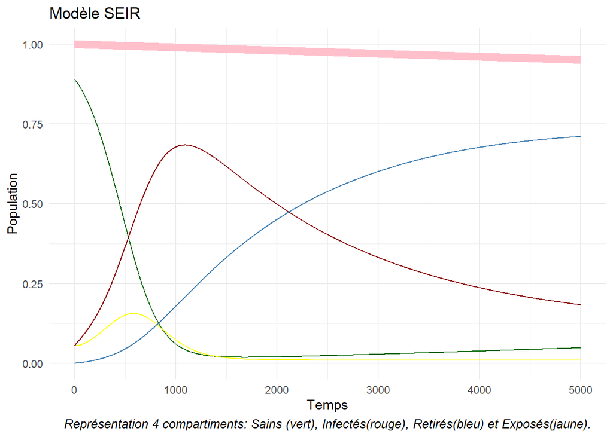

```r
theme_set(theme_minimal())

ggplot(dfseir, aes(x=j)) +                                                    geom_line(aes(y = resS), color = "darkgreen") +                         geom_line(aes(y = resE), color = "yellow")+                             geom_line(aes(y = resI),color = "darkred") +                           geom_line(aes(y = resR), color="steelblue")+geom_line(aes(y = resN), color = "pink",size =3)+ labs(title = "Modèle SEIR", x = "Temps", y="Population", color="L") +    labs(caption = "Représentation 4 compartiments: Sains (vert), Infectés(rouge), Retirés(bleu) et Exposés(jaune).")+                            theme(plot.caption = element_text(hjust = 0.5, face = "italic", size =10))
```

Le pic correspondant au graphe ci dessus :

```r
graphe <- picISeir(0.8,0.05,0.75,dfseir)
print(graphe)
```

```
## $PicI
## [1] 0.6837233
##
## $datePicI
## [1] 1092
##
## $R0pic
## [1] 16
```

Une question se pose : comment calculer tous ces paramètres $\alpha, \beta, \gamma, \mu$ et $\nu$. Ce travail est effectué en collaboration entre les équipes médicales, les épidémiologistes et virologistes, et les mathématiciens. Les taux de natalité et de mortalité peuvent être obtenus grâce au recensement de population.

Il faut, pour cette étude, réaliser en plus un **tirage du taux d’incubation** $\alpha$ :

```r
beta <- tirageBeta(0.1,0.99)
print(beta)
```

```
## [1] 0.5713943
```

```r
gamma <- tirageGamma(0.01,0.99)
print(gamma)
```

```
## [1] 0.2861655
```

```r
alpha <- tirageAlpha(0.01,0.99)
print(alpha)
```

```
## [1] 0.3668122
```

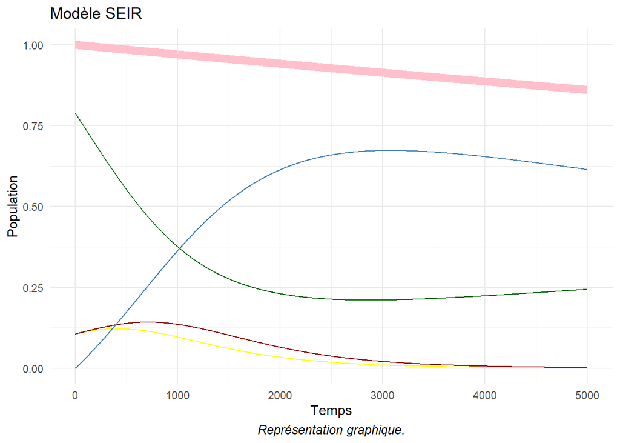

```r
dfseirtest <- seir(50,0.01,0.78855,beta,gamma,alpha,0.008,0.005)


ggplot(dfseirtest, aes(x=j)) +                                                    geom_line(aes(y = resS), color = "darkgreen") +                         geom_line(aes(y = resE), color = "yellow")+                             geom_line(aes(y = resI),color = "darkred") +                           geom_line(aes(y = resR), color="steelblue")+ geom_line(aes(y = resN), color = "pink",size =3)+                               labs(title = "Modèle SEIR", x = "Temps", y="Population", color="L") +    labs(caption = "Représentation graphique.")+theme(plot.caption = element_text(hjust = 0.5, face = "italic", size =10))
```

```r
picISeir(beta,gamma,alpha,dfseirtest)
```

```
## $PicI
## [1] 0.1421783
##
## $datePicI
## [1] 710
##
## $R0pic
## [1] 1.996727
```

```r
picIsimuSeir(50, 0.01, 0.788554,0.01,0.99)
```

| PicI | datePicI | R0pic |
| --- | --- | --- |
| 0.105723 | 1 | 0.5512139 |

```r
list_resSeir <- data.frame(replicate(20,picIsimuSeir(50, 0.01,0.688554,0.01,0.99), simplify=T))
print(list_resSeir)
```

```
##                 X1        X2       X3         X4        X5        X6       X7
## PicI     0.4651554  0.155723 0.155723   0.155723  0.155723 0.6661371 0.155723
## datePicI       722         1        1          1         1      2334        1
## R0pic     6.379583 0.1914042 1.411832 0.08416621 0.7877103  8.179453 1.390938
##                X8        X9       X10       X11       X12       X13       X14
## PicI     0.155723  0.155723 0.2204295 0.1666388  0.155723  0.155723  0.155723
## datePicI        1         1       222        58         1         1         1
## R0pic    1.031294 0.1118406   1.38186 0.5847799 0.1480667 0.7132873 0.5399417
##                X15        X16       X17      X18       X19       X20
## PicI     0.4290961   0.155723 0.4683386 0.155723 0.2148744 0.1596271
## datePicI       687          1       759        1       176        62
## R0pic     4.748364 0.07675529  6.482907 1.008352  1.022616 0.7161189
```

```r
concatSeir <- do.call(rbind.data.frame,list_resSeir)
head(concatSeir)
```

|  | PicI | datePicI | R0pic |
| --- | --- | --- | --- |
| X1 | 0.4651554 | 722 | 6.37958270 |
| X2 | 0.1557230 | 1 | 0.19140415 |
| X3 | 0.1557230 | 1 | 1.41183170 |
| X4 | 0.1557230 | 1 | 0.08416621 |
| X5 | 0.1557230 | 1 | 0.78771027 |
| X6 | 0.6661371 | 2334 | 8.17945281 |

```r
orderConcatSeir <- concatSeir[order(concatSeir[,3],decreasing=F),]
print(orderConcatSeir)
```

```
##          PicI datePicI      R0pic
## X16 0.1557230        1 0.07675529
## X4  0.1557230        1 0.08416621
## X9  0.1557230        1 0.11184055
## X12 0.1557230        1 0.14806667
## X2  0.1557230        1 0.19140415
## X14 0.1557230        1 0.53994170
## X11 0.1666388       58 0.58477993
## X13 0.1557230        1 0.71328731
## X20 0.1596271       62 0.71611894
## X5  0.1557230        1 0.78771027
## X18 0.1557230        1 1.00835232
## X19 0.2148744      176 1.02261600
## X8  0.1557230        1 1.03129448
## X10 0.2204295      222 1.38185993
## X7  0.1557230        1 1.39093772
## X3  0.1557230        1 1.41183170
## X15 0.4290961      687 4.74836353
## X1  0.4651554      722 6.37958270
## X17 0.4683386      759 6.48290679
## X6  0.6661371     2334 8.17945281
```

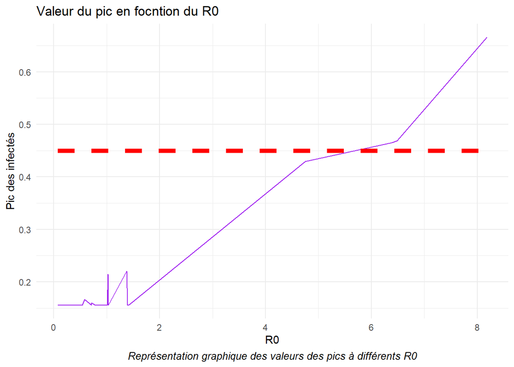

```r
ggplot(orderConcatSeir, aes(x = R0pic)) + geom_line(aes(y = PicI), col="purple")+geom_line(aes(y = 0.45), col="red", linetype = "dashed", size=2)+ labs(title = "Valeur du pic en focntion du R0", x = "R0", y="Pic des infectés", color="red") + labs(caption = "Représentation graphique des valeurs des pics à différents R0")+ theme(plot.caption = element_text(hjust = 0.5, face = "italic", size =10))
```

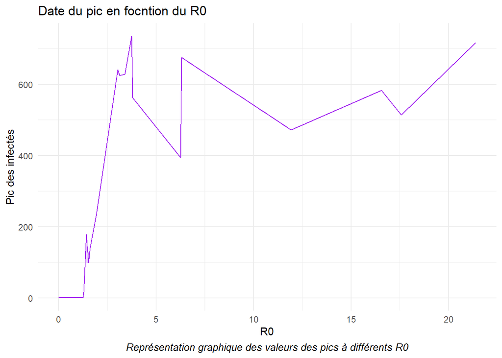

```r
ggplot(orderConcat, aes(x = R0pic)) + geom_line(aes(y = datePicI), col="purple")+ labs(title = "Date du pic en focntion du R0", x = "R0", y="Pic des infectés", color="red") + labs(caption = "Représentation graphique des valeurs des pics à différents R0")+ theme(plot.caption = element_text(hjust = 0.5, face = "italic", size =10))
```